# Homework2 Logistic Regresion

Gustavo Mart?nez, Renato Ram?rez, Erik Larsen and Julio Borja Tecnol?gico de Monterrey

# **The stages of the analysis for the problem are the following:**

1. Business Scenario
2. Data exploration
3. Construction of the model by automatic method
4. The proposed complete model
5. Residuals, DFBetas and Correlation
6. The model for the house segment
7. The model for the car segment
8. Final conclusions

# **1.Business Scenario**

**Business scenario:** Working as a business analyst for a national bank, you are asked to build a model using the available Logistic.sav data (**Available in 2. Datasets for Homework.RData**) that predicts whether your customer defaulted on their loan (i.e., **Default** variable, 0 = Loan in good standing, 1 = Defaulted on loan). Notice there are two types of loans, home and car, so you should consider this variable (i.e., **Loan_Type**) when building your model.

Using the **Logistic.sav** data, use all the available data to build a model that predicts/classifies whether a customer defaulted on their loan (i.e., **Default** variable, 0 = Loan in good standing, 1 = Defaulted on loan). Again, test whether the model predicts/classifies equally well for home and car loans and please provide justification for whether or not the model predicts/classifies equally well across loan types. In your report, briefly describe your modeling building approach and explain using statistics and/or graphs how well the model predicts/classifies whether they defaulted on their loan. **

# **2.Data Exploration**

```
Classes 'tbl_df', 'tbl' and 'data.frame':   4348 obs. of  11 variables:
 $ ID          : num  1 2 3 4 5 6 7 8 9 10 ...
  ..- attr(*, "format.spss")= chr "F5.0"
  ..- attr(*, "display_width")= int 12
 $ Default     : num  0 0 0 0 0 0 0 0 0 0 ...
  ..- attr(*, "format.spss")= chr "F2.0"
  ..- attr(*, "display_width")= int 12
 $ Loan_Type   : chr  "Car" "Home" "Home" "Home" ...
  ..- attr(*, "format.spss")= chr "A4"
  ..- attr(*, "display_width")= int 10
 $ Gender      : chr  "Female" "Female" "Male" "Male" ...
  ..- attr(*, "format.spss")= chr "A6"
 $ Age         : num  30 43 39 39 42 57 41 53 44 57 ...
  ..- attr(*, "format.spss")= chr "F3.0"
  ..- attr(*, "display_width")= int 12
 $ Degree      : chr  "HS" "HS" "HS" "College" ...
  ..- attr(*, "format.spss")= chr "A8"
 $ Income      : num  114885 95770 94220 58946 79754 ...
  ..- attr(*, "format.spss")= chr "F7.0"
  ..- attr(*, "display_width")= int 12
 $ Credit_score: num  641 534 558 622 702 624 594 652 694 586 ...
  ..- attr(*, "format.spss")= chr "F4.0"
  ..- attr(*, "display_width")= int 12
 $ Loan_lenght : num  0 7 5 7 2 3 3 2 3 3 ...
  ..- attr(*, "format.spss")= chr "F3.0"
  ..- attr(*, "display_width")= int 12
 $ Signers     : num  2 2 2 2 1 2 2 2 2 2 ...
  ..- attr(*, "format.spss")= chr "F2.0"
  ..- attr(*, "display_width")= int 12
 $ Citizenship : chr  "Citizen" "Citizen" "Citizen" "Citizen" ...
  ..- attr(*, "format.spss")= chr "A11"
  ..- attr(*, "display_width")= int 11
       ID          Default         Loan_Type            Gender
 Min.   :   1   Min.   :0.00000   Length:4348        Length:4348
 1st Qu.:1091   1st Qu.:0.00000   Class :character   Class :character
 Median :2186   Median :0.00000   Mode  :character   Mode  :character
 Mean   :2185   Mean   :0.06762
 3rd Qu.:3278   3rd Qu.:0.00000
 Max.   :4368   Max.   :1.00000
      Age           Degree              Income        Credit_score
 Min.   :20.00   Length:4348        Min.   : 40217   Min.   :389.0
 1st Qu.:38.00   Class :character   1st Qu.: 84761   1st Qu.:568.0
 Median :42.00   Mode  :character   Median : 96368   Median :610.0
 Mean   :42.38                      Mean   : 96266   Mean   :611.2
 3rd Qu.:47.00                      3rd Qu.:107770   3rd Qu.:654.0
 Max.   :62.00                      Max.   :155953   Max.   :822.0
  Loan_lenght        Signers      Citizenship
 Min.   : 0.000   Min.   :1.000   Length:4348
 1st Qu.: 1.000   1st Qu.:2.000   Class :character
 Median : 2.000   Median :2.000   Mode  :character
 Mean   : 2.666   Mean   :1.904
 3rd Qu.: 4.000   3rd Qu.:2.000
 Max.   :14.000   Max.   :2.000
```

# *3.Build a Model (Step Model, AIC)*

```
stepAIC(object, scope, scale = 0, direction = c(both, backward, forward),
trace = 1, keep = NULL, steps =1000, use.start = FALSE,k = 2, ...)
```

```
Start:  AIC=2153.66
factor(Default) ~ 1

               Df Deviance    AIC     LRT  Pr(>Chi)
+ Credit_score  1   1954.3 1958.3 197.386 < 2.2e-16 ***
+ Income        1   1978.4 1982.4 173.295 < 2.2e-16 ***
+ Degree        2   2044.7 2050.7 107.020 < 2.2e-16 ***
+ Gender        1   2096.7 2100.7  54.950 1.236e-13 ***
+ Age           1   2101.3 2105.3  50.400 1.254e-12 ***
+ Loan_Type     1   2119.0 2123.0  32.660 1.098e-08 ***
+ Citizenship   1   2124.2 2128.2  27.519 1.555e-07 ***
+ Loan_lenght   1   2146.0 2150.0   5.703   0.01694 *
+ Signers       1   2148.7 2152.7   3.017   0.08239 .
<none>              2151.7 2153.7
+ ID            1   2151.7 2155.7   0.011   0.91721
---
Signif. codes:  0 '***' 0.001 '**' 0.01 '*' 0.05 '.' 0.1 ' ' 1

Step:  AIC=1958.28
factor(Default) ~ Credit_score

               Df Deviance    AIC     LRT  Pr(>Chi)
+ Income        1   1860.5 1866.5  93.762 < 2.2e-16 ***
+ Degree        2   1891.9 1899.9  62.384 2.841e-14 ***
+ Gender        1   1933.2 1939.2  21.053 4.467e-06 ***
+ Loan_Type     1   1935.8 1941.8  18.498 1.701e-05 ***
+ Citizenship   1   1946.7 1952.7   7.568  0.005943 **
+ Age           1   1946.8 1952.8   7.502  0.006163 **
+ Loan_lenght   1   1948.7 1954.7   5.610  0.017854 *
+ Signers       1   1951.6 1957.6   2.667  0.102476
<none>              1954.3 1958.3
+ ID            1   1954.3 1960.3   0.015  0.901408
- Credit_score  1   2151.7 2153.7 197.386 < 2.2e-16 ***
---
Signif. codes:  0 '***' 0.001 '**' 0.01 '*' 0.05 '.' 0.1 ' ' 1

Step:  AIC=1866.52
factor(Default) ~ Credit_score + Income

               Df Deviance    AIC     LRT  Pr(>Chi)
```

[output cut: 72 more lines]

```

               Df Deviance    AIC    LRT  Pr(>Chi)
<none>              1798.4 1814.4
+ Age           1   1798.3 1816.3  0.066  0.796944
- Gender        1   1802.3 1816.3  3.935  0.047281 *
+ Citizenship   1   1798.4 1816.4  0.031  0.860031
+ Loan_Type     1   1798.4 1816.4  0.026  0.872617
+ ID            1   1798.4 1816.4  0.008  0.927280
- Signers       1   1804.3 1818.3  5.847  0.015602 *
- Loan_lenght   1   1806.3 1820.3  7.903  0.004935 **
- Degree        2   1835.9 1847.9 37.501 7.189e-09 ***
- Income        1   1873.4 1887.4 74.960 < 2.2e-16 ***
- Credit_score  1   1891.3 1905.3 92.897 < 2.2e-16 ***
---
Signif. codes:  0 '***' 0.001 '**' 0.01 '*' 0.05 '.' 0.1 ' ' 1
```

```
Call:
glm(formula = factor(Default) ~ Credit_score + Income + Degree +
    Loan_lenght + Signers + Gender, family = binomial(link = "logit"),
    data = Data.omit)

Deviance Residuals:
    Min       1Q   Median       3Q      Max
-1.6353  -0.3784  -0.2533  -0.1644   3.0516

Coefficients:
                 Estimate Std. Error z value Pr(>|z|)
(Intercept)    -1.328e+01  9.888e-01 -13.434  < 2e-16 ***
Credit_score    1.080e-02  1.150e-03   9.394  < 2e-16 ***
Income          3.522e-05  4.151e-06   8.485  < 2e-16 ***
DegreeGradaute  3.808e-01  2.124e-01   1.793  0.07295 .
DegreeHS       -6.990e-01  1.401e-01  -4.990 6.05e-07 ***
Loan_lenght    -7.021e-02  2.604e-02  -2.696  0.00702 **
Signers         4.703e-01  2.017e-01   2.332  0.01972 *
GenderMale     -2.704e-01  1.366e-01  -1.979  0.04776 *
---
Signif. codes:  0 '***' 0.001 '**' 0.01 '*' 0.05 '.' 0.1 ' ' 1

(Dispersion parameter for binomial family taken to be 1)

    Null deviance: 2151.7  on 4347  degrees of freedom
Residual deviance: 1798.4  on 4340  degrees of freedom
AIC: 1814.4

Number of Fisher Scoring iterations: 6
```

## ROC Curves

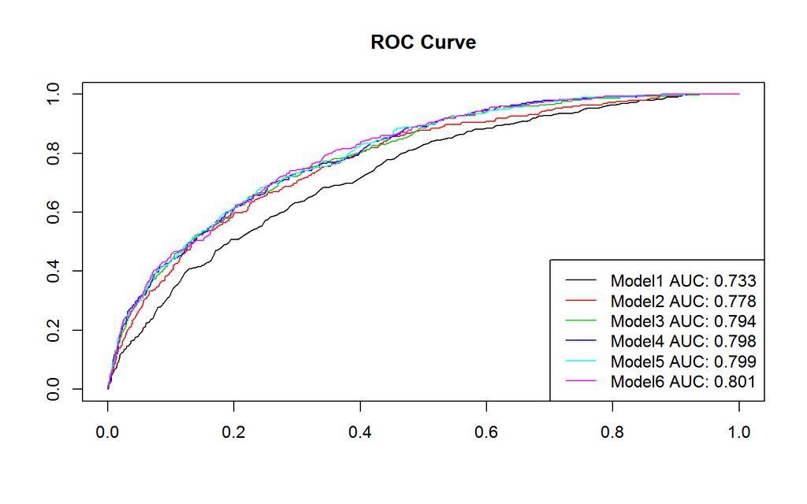

```
[[1]]
Default ~ Credit_score

[[2]]
Default ~ Credit_score + Income

[[3]]
Default ~ Credit_score + Income + Degree

[[4]]
Default ~ Credit_score + Income + Degree + Loan_lenght

[[5]]
Default ~ Credit_score + Income + Degree + Loan_lenght + Signers

[[6]]
Default ~ Credit_score + Income + Degree + Loan_lenght + Signers +
    Gender

[[1]]
NULL

[[2]]
NULL

[[3]]
NULL

[[4]]
NULL

[[5]]
NULL

[[6]]
NULL
```

ROC Curve (a graphical plot of sensivity and false positive fraction) , shows Model 6 is the best with the biggest AUC (Area Under Curve) between 0.8 and 0.9 is “good.

We select the critical variables of stage 1 (automatic method). A logistic regression model is proposed to predict the default of home loans. The model includes the following variables: Credit_score + Income + Gender + Degree.

```r
str(Logistic)
```

```
Classes 'tbl_df', 'tbl' and 'data.frame':   4348 obs. of  11 variables:
 $ ID          : num  1 2 3 4 5 6 7 8 9 10 ...
  ..- attr(*, "format.spss")= chr "F5.0"
  ..- attr(*, "display_width")= int 12
 $ Default     : num  0 0 0 0 0 0 0 0 0 0 ...
  ..- attr(*, "format.spss")= chr "F2.0"
  ..- attr(*, "display_width")= int 12
 $ Loan_Type   : chr  "Car" "Home" "Home" "Home" ...
  ..- attr(*, "format.spss")= chr "A4"
  ..- attr(*, "display_width")= int 10
 $ Gender      : chr  "Female" "Female" "Male" "Male" ...
  ..- attr(*, "format.spss")= chr "A6"
 $ Age         : num  30 43 39 39 42 57 41 53 44 57 ...
  ..- attr(*, "format.spss")= chr "F3.0"
  ..- attr(*, "display_width")= int 12
 $ Degree      : chr  "HS" "HS" "HS" "College" ...
  ..- attr(*, "format.spss")= chr "A8"
 $ Income      : num  114885 95770 94220 58946 79754 ...
  ..- attr(*, "format.spss")= chr "F7.0"
  ..- attr(*, "display_width")= int 12
 $ Credit_score: num  641 534 558 622 702 624 594 652 694 586 ...
  ..- attr(*, "format.spss")= chr "F4.0"
  ..- attr(*, "display_width")= int 12
 $ Loan_lenght : num  0 7 5 7 2 3 3 2 3 3 ...
  ..- attr(*, "format.spss")= chr "F3.0"
  ..- attr(*, "display_width")= int 12
 $ Signers     : num  2 2 2 2 1 2 2 2 2 2 ...
  ..- attr(*, "format.spss")= chr "F2.0"
  ..- attr(*, "display_width")= int 12
 $ Citizenship : chr  "Citizen" "Citizen" "Citizen" "Citizen" ...
  ..- attr(*, "format.spss")= chr "A11"
  ..- attr(*, "display_width")= int 11
```

```r
summary(Logistic)
```

```
       ID          Default         Loan_Type            Gender
 Min.   :   1   Min.   :0.00000   Length:4348        Length:4348
 1st Qu.:1091   1st Qu.:0.00000   Class :character   Class :character
 Median :2186   Median :0.00000   Mode  :character   Mode  :character
 Mean   :2185   Mean   :0.06762
 3rd Qu.:3278   3rd Qu.:0.00000
 Max.   :4368   Max.   :1.00000
      Age           Degree              Income        Credit_score
 Min.   :20.00   Length:4348        Min.   : 40217   Min.   :389.0
 1st Qu.:38.00   Class :character   1st Qu.: 84761   1st Qu.:568.0
 Median :42.00   Mode  :character   Median : 96368   Median :610.0
 Mean   :42.38                      Mean   : 96266   Mean   :611.2
 3rd Qu.:47.00                      3rd Qu.:107770   3rd Qu.:654.0
 Max.   :62.00                      Max.   :155953   Max.   :822.0
  Loan_lenght        Signers      Citizenship
 Min.   : 0.000   Min.   :1.000   Length:4348
 1st Qu.: 1.000   1st Qu.:2.000   Class :character
 Median : 2.000   Median :2.000   Mode  :character
 Mean   : 2.666   Mean   :1.904
 3rd Qu.: 4.000   3rd Qu.:2.000
 Max.   :14.000   Max.   :2.000
```

```r
View(Logistic)
```